# Multiple linear regression

## —————————————————————————

### **Student Name :** Sachid Deshmukh

### **Date :** 12/14/2018

- > [GitHub Location for rmd file](https://github.com/mlforsachid/MSDSQ1/blob/master/Data606/Week9/Lab8/SachidVijay.Deshmukh60.Rmd)
- > [GitHub Location for pdf file](https://github.com/mlforsachid/MSDSQ1/blob/master/Data606/Week9/Lab8/SachidVijay.Deshmukh60.pdf)
- > [RPubs location of published file](http://rpubs.com/sachid/Data606Lab8)

## —————————————————————————

## Grading the professor

Many college courses conclude by giving students the opportunity to evaluate the course and the instructor anonymously. However, the use of these student evaluations as an indicator of course quality and teaching effectiveness is often criticized because these measures may reflect the influence of non-teaching related characteristics, such as the physical appearance of the instructor. The article titled, “Beauty in the classroom: instructors’ pulchritude and putative pedagogical productivity” (Hamermesh and Parker, 2005) found that instructors who are viewed to be better looking receive higher instructional ratings. (Daniel S. Hamermesh, Amy Parker, Beauty in the classroom: instructors pulchritude and putative pedagogical productivity, *Economics of Education Review*, Volume 24, Issue 4, August 2005, Pages 369-376, ISSN 0272-7757, 10.1016/j.econedurev.2004.07.013. http://www.sciencedirect.com/science/article/pii/S0272775704001165.)

In this lab we will analyze the data from this study in order to learn what goes into a positive professor evaluation.

## The data

The data were gathered from end of semester student evaluations for a large sample of professors from the University of Texas at Austin. In addition, six students rated the professors’ physical appearance. (This is aslightly modified version of the original data set that was released as part of the replication data for *Data Analysis Using Regression and Multilevel/Hierarchical Models* (Gelman and Hill, 2007).) The result is a data frame where each row contains a different course and columns represent variables about the courses and professors.

```r
load("more/evals.RData")
```

| variable | description |
| --- | --- |
| `score` | average professor evaluation score: (1) very unsatisfactory - (5) excellent. |
| `rank` | rank of professor: teaching, tenure track, tenured. |
| `ethnicity` | ethnicity of professor: not minority, minority. |
| `gender` | gender of professor: female, male. |
| `language` | language of school where professor received education: english or non-english. |
| `age` | age of professor. |
| `cls_perc_eval` | percent of students in class who completed evaluation. |
| `cls_did_eval` | number of students in class who completed evaluation. |
| `cls_students` | total number of students in class. |
| `cls_level` | class level: lower, upper. |
| `cls_profs` | number of professors teaching sections in course in sample: single, multiple. |
| `cls_credits` | number of credits of class: one credit (lab, PE, etc.), multi credit. |
| `bty_f1lower` | beauty rating of professor from lower level female: (1) lowest - (10) highest. |
| `bty_f1upper` | beauty rating of professor from upper level female: (1) lowest - (10) highest. |
| `bty_f2upper` | beauty rating of professor from second upper level female: (1) lowest - (10) highest. |
| `bty_m1lower` | beauty rating of professor from lower level male: (1) lowest - (10) highest. |
| `bty_m1upper` | beauty rating of professor from upper level male: (1) lowest - (10) highest. |
| `bty_m2upper` | beauty rating of professor from second upper level male: (1) lowest - (10) highest. |
| `bty_avg` | average beauty rating of professor. |
| `pic_outfit` | outfit of professor in picture: not formal, formal. |
| `pic_color` | color of professor’s picture: color, black & white. |

## Exploring the data

1. Is this an observational study or an experiment? The original research question posed in the paper is whether beauty leads directly to the differences in course evaluations. Given the study design, is it possible to answer this question as it is phrased? If not, rephrase the question.

**Answer: This is an observational study. This observational study is conducted with multiple independent variables and cumulative impact of those variables on course evaluation (output variable), Due to this nature of the study it is not feasible to answer a very specific question whether beauty of the teacher alone leads to differences in the course evaluations. We can re-phrase the question as Which variables amogst those collected in observational study leads to differences in the course evaluations and by what magnitude**

2. Describe the distribution of `score`. Is the distribution skewed? What does that tell you about how students rate courses? Is this what you expected to see? Why, or why not?

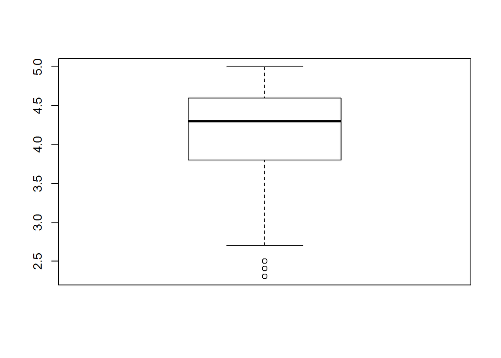

```r
boxplot(evals$score)
```

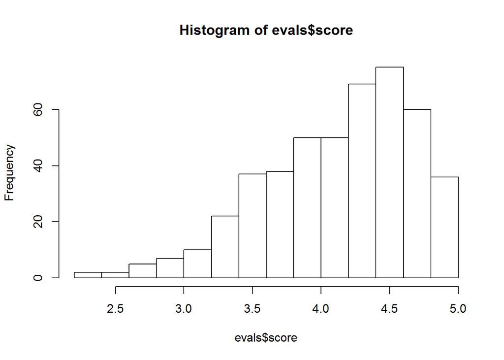

```r
hist(evals$score)
```

3. Excluding `score`, select two other variables and describe their relationship using an appropriate visualization (scatterplot, side-by-side boxplots, or mosaic plot).

[figure not shown]

```r
fit = lm(evals$cls_students~evals$cls_did_eval)
plot(evals$cls_students~evals$cls_did_eval, xlab="Total Students", ylab="Students Completed Evaluation", main="Total Students vs Students completed evaluation")
abline(coefficients(fit), lty=2, col="blue")
```

**Answer: The above scatter plot shows relationship between Total Students and Students who completed evaluation. From the scatter plot it can be seen that higher students particiapate in teachers evaluation as class size increased. This shows that there is a positive correlation between Total Students and Students particiapted in evaluation**